# Análisis Coyuntural de Chile

Andrés Durán S.

duransalgado.andres@gmail.com

domingo 04 de septiembre, 2022

# 1 Evolución del IPC y de la TPM

En julio de 2022 el índice de precios al consumidor (IPC) anotó una variación mensual de 1,4%, y un incremento a doce meses de 13,1%, mientras que la tasa de interés de política monetaria se ubica en 9,43%.

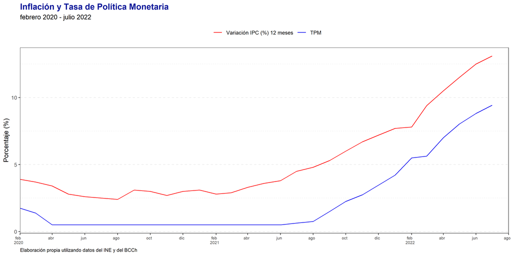

# 2 Variaciones e Incidencias por división

IPC Total julio 2022

| División | Ponderación | Índice | Variación mensual | Variación acumulada | Variación 12 meses | Incidencia mensual | Incidencia 12 meses |
| --- | --- | --- | --- | --- | --- | --- | --- |
| alimentos y bebidas no alcohólicas | 19.30131 | 137.00 | 1.9 | 15.4 | 19.4 | 0.393 | 3.920 |
| bebidas alcohólicas y tabaco | 4.77767 | 115.22 | 1.1 | 6.6 | 5.4 | 0.048 | 0.259 |
| vestuario y calzado | 3.50596 | 98.18 | -2.7 | -2.0 | -0.3 | -0.079 | -0.009 |
| vivienda y servicios básicos | 14.82720 | 122.98 | 1.3 | 7.2 | 10.7 | 0.188 | 1.605 |
| equipamiento y mantención del hogar | 6.52285 | 117.93 | 0.4 | 3.7 | 5.8 | 0.024 | 0.383 |
| salud | 7.76778 | 112.81 | 0.5 | 4.1 | 5.2 | 0.038 | 0.392 |
| transporte | 13.12148 | 140.01 | 3.4 | 14.8 | 26.4 | 0.492 | 3.499 |
| comunicaciones | 5.45488 | 88.65 | 0.0 | -4.7 | -5.1 | 0.002 | -0.237 |
| recreacion y cultura | 6.58912 | 126.92 | 1.7 | 3.1 | 16.4 | 0.112 | 1.072 |
| educación | 6.59568 | 119.97 | 0.0 | 6.8 | 7.0 | 0.000 | 0.472 |
| restaurantes y hoteles | 6.38347 | 129.27 | 1.1 | 10.3 | 18.6 | 0.075 | 1.181 |
| bienes y servicios diversos | 5.15260 | 123.20 | 1.6 | 7.8 | 11.3 | 0.081 | 0.588 |

# 3 Divisiones

- División 7 de transporte

Transporte anoto aumentos mensuales en 8 de sus 10 clases. La más importante fue combustibles y lubricantes para vehículos de transporte personal(4,6%) que incidió 0,175 pp., mientras que transporte de pasajeros por vías urbanas y carreteras(5,5%) contribuyó 0,129 pp.

- División 1 de alimentos y bebidas no alcohólicas

Alimentos y bebidas no alcohólicas consignó alzas mensuales en 10 de sus 11 clases. La más importante fue carnes(3,1%) que aportó 0,155pp., seguida de frutas(5,1%) con 0,053pp.

- División 4 de vivienda y servicios básicos

Vivienda y servicios básicos registró aumentos mensuales en 7 de sus 9 clases. La más importante fue electricidad(3,7%) que aportó 0,077pp., seguida de gas(2,7%) con 0,051pp.

# 4 Productos

- Automóvil nuevo

Anotó un aumento mensual de 2,7%, con una incidencia de 0,090 pp., y variaciones de 12,7% y de 26,5% a doce meses.

- Servicio de transporte en bus interurbano

Registró un alza mensual de 14,4% con 0,086 pp., acumulando 11,6% en lo que va del año y 43,0% a doce meses.

- Electricidad

Consignó un alza mensual de 3,7%, con 0,077 pp., acumulando 4,1% en lo que va del año y 4,2% a doce meses.

- Carne de vacuno

Consigno un aumento mensual de 3,2%, con una incidencia de 0,075 pp., registrando una variación de 11,0% en lo que va del año y de 26,3% a doce meses

- Servicio de transporte aéreo

Registró una aumento mensual de 5%, con 0,064 pp., acumulando 50,3% en lo que va del año y 142,7% a doce meses.

# 5 Evolución del Salario Real y la Inflación en doce meses

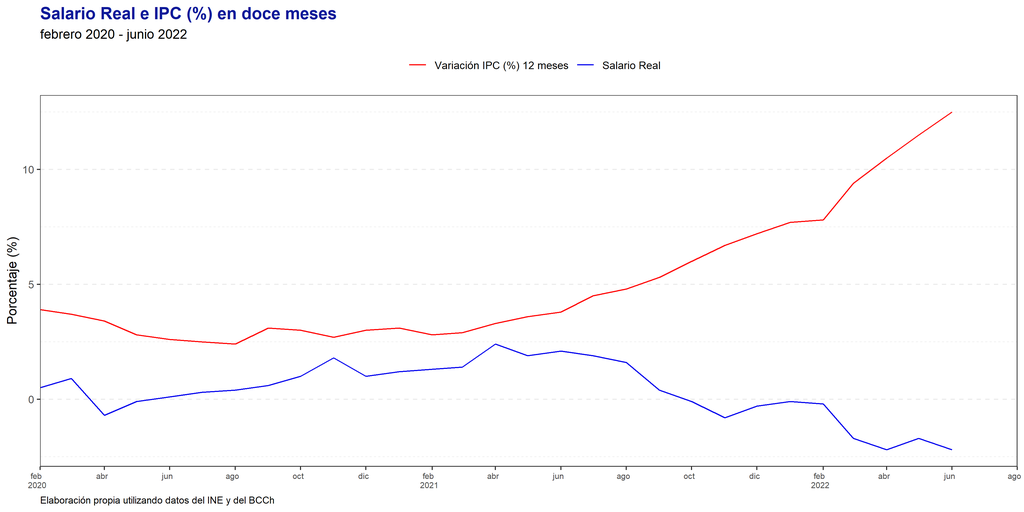

# 6 Expectativas de inflación en las encuestas (*)

La Encuesta de Expectativas Económica (EEE), la Encuesta de Operadores Financieros (EOF) y los seguros de inflación la ubican entre 7,1% y 7,8% a doce meses. A dos años plazo, las compensaciones inflacionarias y las encuestas -EEE y EOF- se ubicaron hasta cifras entre 4,0% y 4,6%.

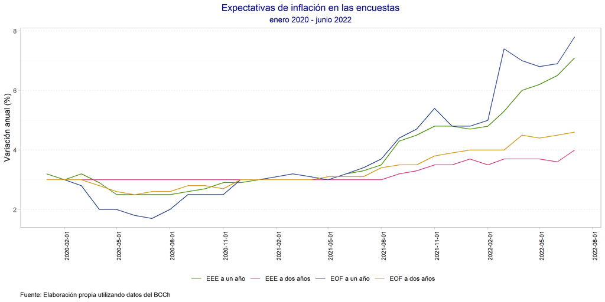

(*) En el caso de la EOF, considera la encuesta de la primera quincena de cada mes hasta enero del 2018. Desde febrero de ese año, considera la última encuesta publicada en el mes, incluyendo la previa a la Reunión de Política Monetaria de diciembre 2021. En los meses en los que no se publica encuesta, se considera la última encuesta disponible. En el caso de la EEE, considera la encuesta publicada en diciembre de 2021.

# 7 Comparación con otros países